# Exploratory Data Analysis and Principal Component Analysis of Household Electricity Consumption Patterns

Mary Karanja-2023331

22 November 2026

```r
library(tidyverse)
library(lubridate)
library(corrplot)
library(factoextra)
library(knitr)
```

# 1. Introduction and problem domain

Electricity use in a home changes with the time of day, the season and the appliances in use. Smart meters now record this use every minute, which gives a large amount of data about how households consume energy. Understanding these patterns helps energy suppliers plan demand and helps households find ways to reduce waste.

This project analyses minute-level electricity measurements from one household. The data has several electrical variables that are related to each other, so it is a good case for exploratory data analysis (EDA) and for Principal Component Analysis (PCA).

# 2. Research motivation and research questions

Household electricity data is large, and many of its variables measure related things. Before building any model, it is useful to check data quality, look at patterns over time and see whether the variables can be summarised with fewer dimensions.

**Main research question:** How do household electricity consumption patterns vary over time, and which electrical measurements contribute most to the variation in household energy consumption?

**Supporting research questions:**

1. How does electricity consumption vary throughout the day and across different months?
2. Which electrical measurements have the strongest relationships with each other?
3. Are there unusual electricity consumption patterns or outliers?
4. Which variables contribute most to the overall variation in electricity consumption?
5. Can PCA reduce dimensionality while retaining most of the information?

# 3. Dataset description and source

The data is the *Individual Household Electric Power Consumption* dataset from the UCI Machine Learning Repository (Hebrail and Berard, 2012). It contains measurements from one house, recorded every minute between December 2006 and November 2010. The file is read from `data_path` below.

| Variable | Description | Unit |
| --- | --- | --- |
| Date | Date of the measurement (dd/mm/yyyy) | date |
| Time | Time of the measurement (hh:mm:ss) | time |
| Global_active_power | Household global minute-averaged active power | kilowatts |
| Global_reactive_power | Household global minute-averaged reactive power | kilowatts |
| Voltage | Minute-averaged voltage | volts |
| Global_intensity | Household global minute-averaged current intensity | amperes |
| Sub_metering_1 | Kitchen (dishwasher, oven, microwave) | watt-hours |
| Sub_metering_2 | Laundry room (washing machine, tumble-dryer, refrigerator, lighting) | watt-hours |
| Sub_metering_3 | Electric water heater and air conditioner | watt-hours |

The file uses semicolons as separators and writes missing numeric values as `?`. The data represents a single household, so the results describe this home and not households in general.

```r
# Location of the data file
data_path <- "household_power_consumption.txt"

# Read the file, treat "?" as missing and set the column types
power <- read_delim(
  data_path,
  delim = ";",
  na = "?",
  col_types = cols(
    Date = col_character(),
    Time = col_character(),
    .default = col_double()
  )
)
```

# 4. Initial dataset exploration

```r
# Dimensions
dim(power)
```

```
## [1] 2075259       9
```

```r
# Column names and types
glimpse(power)
```

```
## Rows: 2,075,259
## Columns: 9
## $ Date                  <chr> "16/12/2006", "16/12/2006", "16/12/2006", "16/12…
## $ Time                  <chr> "17:24:00", "17:25:00", "17:26:00", "17:27:00", …
## $ Global_active_power   <dbl> 4.216, 5.360, 5.374, 5.388, 3.666, 3.520, 3.702,…
## $ Global_reactive_power <dbl> 0.418, 0.436, 0.498, 0.502, 0.528, 0.522, 0.520,…
## $ Voltage               <dbl> 234.84, 233.63, 233.29, 233.74, 235.68, 235.02, …
## $ Global_intensity      <dbl> 18.4, 23.0, 23.0, 23.0, 15.8, 15.0, 15.8, 15.8, …
## $ Sub_metering_1        <dbl> 0, 0, 0, 0, 0, 0, 0, 0, 0, 0, 0, 0, 0, 0, 0, 0, …
## $ Sub_metering_2        <dbl> 1, 1, 2, 1, 1, 2, 1, 1, 1, 2, 1, 1, 1, 2, 1, 0, …
## $ Sub_metering_3        <dbl> 17, 16, 17, 17, 17, 17, 17, 17, 17, 16, 17, 17, …
```

```r
# First rows
head(power)
```

| Date | Time | Global_active_power | Global_reactive_power | Voltage | Global_intensity | Sub_metering_1 | Sub_metering_2 | Sub_metering_3 |
| --- | --- | --- | --- | --- | --- | --- | --- | --- |
| 16/12/2006 | 17:24:00 | 4.216 | 0.418 | 234.84 | 18.4 | 0 | 1 | 17 |
| 16/12/2006 | 17:25:00 | 5.360 | 0.436 | 233.63 | 23.0 | 0 | 1 | 16 |
| 16/12/2006 | 17:26:00 | 5.374 | 0.498 | 233.29 | 23.0 | 0 | 2 | 17 |
| 16/12/2006 | 17:27:00 | 5.388 | 0.502 | 233.74 | 23.0 | 0 | 1 | 17 |
| 16/12/2006 | 17:28:00 | 3.666 | 0.528 | 235.68 | 15.8 | 0 | 1 | 17 |
| 16/12/2006 | 17:29:00 | 3.520 | 0.522 | 235.02 | 15.0 | 0 | 2 | 17 |

```r
# Summary of each variable
summary(power)
```

```
##         Date                Time         Global_active_power
##  Length   :2075259   Length   :2075259   Min.   : 0.076
##  N.unique :   1442   N.unique :   1440   1st Qu.: 0.308
##  N.blank  :      0   N.blank  :      0   Median : 0.602
##  Min.nchar:      8   Min.nchar:      8   Mean   : 1.092
##  Max.nchar:     10   Max.nchar:      8   3rd Qu.: 1.528
##                                          Max.   :11.122
##                                          NAs    :25979
##  Global_reactive_power    Voltage      Global_intensity Sub_metering_1
##  Min.   :0.0000        Min.   :223.2   Min.   : 0.200   Min.   : 0.000
##  1st Qu.:0.0480        1st Qu.:239.0   1st Qu.: 1.400   1st Qu.: 0.000
##  Median :0.1000        Median :241.0   Median : 2.600   Median : 0.000
##  Mean   :0.1237        Mean   :240.8   Mean   : 4.628   Mean   : 1.122
##  3rd Qu.:0.1940        3rd Qu.:242.9   3rd Qu.: 6.400   3rd Qu.: 0.000
##  Max.   :1.3900        Max.   :254.2   Max.   :48.400   Max.   :88.000
##  NAs    :25979         NAs    :25979   NAs    :25979    NAs    :25979
##  Sub_metering_2   Sub_metering_3
##  Min.   : 0.000   Min.   : 0.000
##  1st Qu.: 0.000   1st Qu.: 0.000
##  Median : 0.000   Median : 1.000
##  Mean   : 1.299   Mean   : 6.458
##  3rd Qu.: 1.000   3rd Qu.:17.000
##  Max.   :80.000   Max.   :31.000
##  NAs    :25979    NAs    :25979
```

The dataset has 2,075,259 rows and 9 columns before cleaning.

# 5. Data cleaning and preparation

The Date and Time columns are stored as text, so they are combined and converted to a date-time. Time features are then created for the later analysis.

```r
# Names of the continuous measurement variables
num_vars <- c("Global_active_power", "Global_reactive_power", "Voltage",
              "Global_intensity", "Sub_metering_1", "Sub_metering_2",
              "Sub_metering_3")

# Combine Date and Time into one date-time column
power <- power %>%
  mutate(DateTime = dmy_hms(paste(Date, Time)),
         Date = dmy(Date)) %>%
  select(-Time)

# Check that all dates were parsed
sum(is.na(power$DateTime))
```

```
## [1] 0
```

```r
range(power$DateTime)
```

```
## [1] "2006-12-16 17:24:00 UTC" "2010-11-26 21:02:00 UTC"
```

```r
# Create time features
power <- power %>%
  mutate(Hour = hour(DateTime),
         Weekday = wday(Date, label = TRUE, week_start = 1),
         Month = month(Date, label = TRUE),
         Year = year(Date),
         Day_Type = if_else(Weekday %in% c("Sat", "Sun"), "Weekend", "Weekday"))

# Check the new columns
power %>% select(DateTime, Hour, Weekday, Month, Year, Day_Type) %>% head()
```

| DateTime | Hour | Weekday | Month | Year | Day_Type |
| --- | --- | --- | --- | --- | --- |
| 2006-12-16 17:24:00 | 17 | Sat | Dec | 2006 | Weekend |
| 2006-12-16 17:25:00 | 17 | Sat | Dec | 2006 | Weekend |
| 2006-12-16 17:26:00 | 17 | Sat | Dec | 2006 | Weekend |
| 2006-12-16 17:27:00 | 17 | Sat | Dec | 2006 | Weekend |
| 2006-12-16 17:28:00 | 17 | Sat | Dec | 2006 | Weekend |
| 2006-12-16 17:29:00 | 17 | Sat | Dec | 2006 | Weekend |

# 6. Missing value analysis and treatment

```r
# Missing values in each column
missing_table <- tibble(
  Variable = names(power),
  Missing = colSums(is.na(power)),
  Percent = round(100 * colSums(is.na(power)) / nrow(power), 2)
)
kable(missing_table)
```

| Variable | Missing | Percent |
| --- | --- | --- |
| Date | 0 | 0.00 |
| Global_active_power | 25979 | 1.25 |
| Global_reactive_power | 25979 | 1.25 |
| Voltage | 25979 | 1.25 |
| Global_intensity | 25979 | 1.25 |
| Sub_metering_1 | 25979 | 1.25 |
| Sub_metering_2 | 25979 | 1.25 |
| Sub_metering_3 | 25979 | 1.25 |
| DateTime | 0 | 0.00 |
| Hour | 0 | 0.00 |
| Weekday | 0 | 0.00 |
| Month | 0 | 0.00 |
| Year | 0 | 0.00 |
| Day_Type | 0 | 0.00 |

```r
# Number of measurement variables missing in each row
table(rowSums(is.na(power[, num_vars])))
```

```
##
##       0       7
## 2049280   25979
```

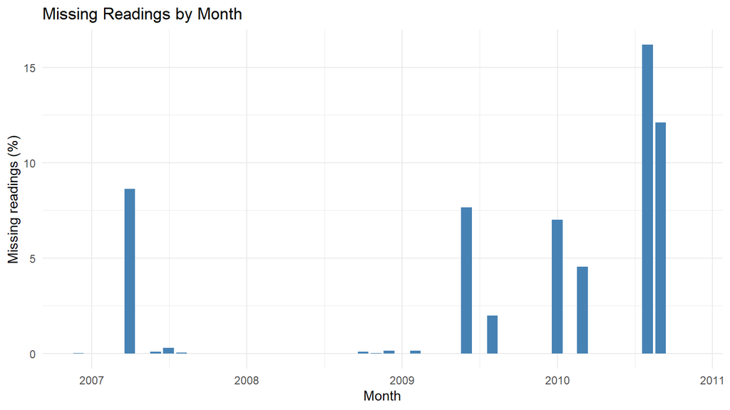

```r
# Percentage of missing rows in each month
missing_by_month <- power %>%
  mutate(YearMonth = floor_date(DateTime, "month")) %>%
  group_by(YearMonth) %>%
  summarise(Missing_Percent = 100 * mean(is.na(Global_active_power)))

ggplot(missing_by_month, aes(x = YearMonth, y = Missing_Percent)) +
  geom_col(fill = "steelblue") +
  labs(title = "Missing Readings by Month",
       x = "Month", y = "Missing readings (%)") +
  theme_minimal()
```

```r
# Length of each run of consecutive missing minutes
runs <- rle(is.na(power$Global_active_power))
gap_lengths <- runs$lengths[runs$values]

summary(gap_lengths)
```

```
##    Min. 1st Qu.  Median    Mean 3rd Qu.    Max.
##     1.0     1.0     1.0   365.9     3.0  7226.0
```

```r
max(gap_lengths)
```

```
## [1] 7226
```

Filling the missing minutes with the mean or median would create readings that were never recorded, and it would flatten the daily pattern. The treatment is chosen after looking at the table, the pattern table and the gap lengths above.

```r
rows_before <- nrow(power)

# Remove rows with missing measurements
power <- power %>% drop_na(all_of(num_vars))

rows_after <- nrow(power)
c(Before = rows_before, After = rows_after, Removed = rows_before - rows_after)
```

```
##  Before   After Removed
## 2075259 2049280   25979
```

# 7. Duplicate and data type checks

```r
# Duplicate rows and duplicate timestamps
sum(duplicated(power))
```

```
## [1] 0
```

```r
sum(duplicated(power$DateTime))
```

```
## [1] 0
```

```r
# Remove duplicate rows if any exist
if (sum(duplicated(power)) > 0) {
  power <- distinct(power)
}
```

```r
# Data types
sapply(power, function(x) class(x)[1])
```

```
##                  Date   Global_active_power Global_reactive_power
##                "Date"             "numeric"             "numeric"
##               Voltage      Global_intensity        Sub_metering_1
##             "numeric"             "numeric"             "numeric"
##        Sub_metering_2        Sub_metering_3              DateTime
##             "numeric"             "numeric"             "POSIXct"
##                  Hour               Weekday                 Month
##             "integer"             "ordered"             "ordered"
##                  Year              Day_Type
##             "numeric"           "character"
```

```r
# Minimum values, to look for impossible readings
sapply(power[, num_vars], min)
```

```
##   Global_active_power Global_reactive_power               Voltage
##                 0.076                 0.000               223.200
##      Global_intensity        Sub_metering_1        Sub_metering_2
##                 0.200                 0.000                 0.000
##        Sub_metering_3
##                 0.000
```

```r
# Seconds between consecutive readings
gaps <- as.numeric(diff(power$DateTime), units = "secs")
table(gaps == 60)
```

```
##
##   FALSE    TRUE
##      71 2049208
```

# 8. Outlier detection and treatment

```r
# Random sample used for plots that are slow with the full data
set.seed(123)
power_sample <- slice_sample(power, n = 50000)
```

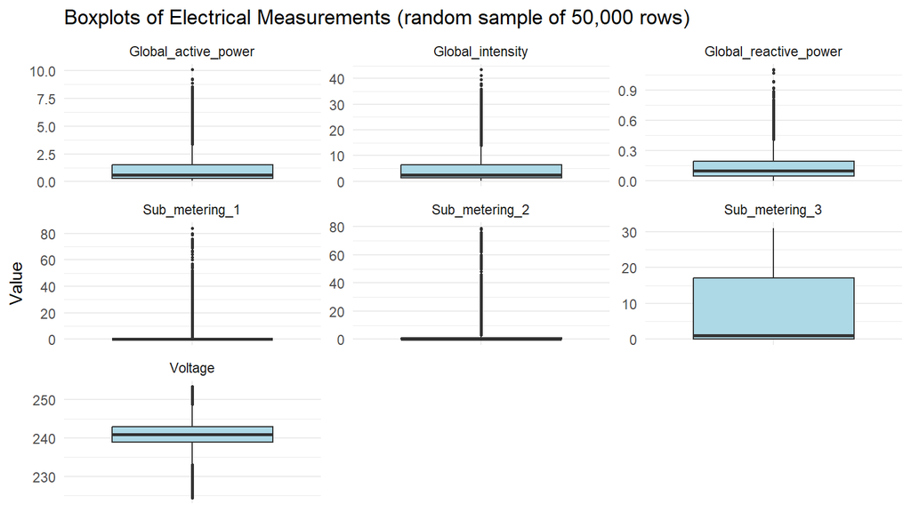

```r
# Boxplots of each variable
power_sample %>%
  select(all_of(num_vars)) %>%
  pivot_longer(everything(), names_to = "Variable", values_to = "Value") %>%
  ggplot(aes(x = Variable, y = Value)) +
  geom_boxplot(fill = "lightblue", outlier.size = 0.5) +
  facet_wrap(~ Variable, scales = "free") +
  labs(title = "Boxplots of Electrical Measurements (random sample of 50,000 rows)",
       x = NULL, y = "Value") +
  theme_minimal() +
  theme(axis.text.x = element_blank())
```

```r
# Count outliers using the 1.5 x IQR rule
count_outliers <- function(x) {
  q <- quantile(x, c(0.25, 0.75))
  iqr <- q[2] - q[1]
  sum(x < q[1] - 1.5 * iqr | x > q[2] + 1.5 * iqr)
}

outlier_table <- tibble(
  Variable = num_vars,
  Outliers = sapply(power[, num_vars], count_outliers)
) %>%
  mutate(Percent = round(100 * Outliers / nrow(power), 2))
kable(outlier_table)
```

| Variable | Outliers | Percent |
| --- | --- | --- |
| Global_active_power | 94907 | 4.63 |
| Global_reactive_power | 40420 | 1.97 |
| Voltage | 51067 | 2.49 |
| Global_intensity | 100961 | 4.93 |
| Sub_metering_1 | 169105 | 8.25 |
| Sub_metering_2 | 77151 | 3.76 |
| Sub_metering_3 | 0 | 0.00 |

```r
# Upper percentiles of active power
quantile(power$Global_active_power, c(0.5, 0.9, 0.99, 0.999, 1))
```

```
##    50%    90%    99%  99.9%   100%
##  0.602  2.470  4.850  6.790 11.122
```

The high readings are likely to come from real appliance use, so removing them would remove the patterns this project is studying. The outliers are therefore kept, and only impossible values would be removed. Section 13 looks at when the high readings happen. Because PCA is sensitive to extreme values, this is also discussed in the limitations.

```r
# Check the cleaned data meets the size requirement
tibble(Rows = nrow(power),
       Columns = ncol(power),
       Meets_Requirement = nrow(power) >= 3000 & length(num_vars) >= 7)
```

| Rows | Columns | Meets_Requirement |
| --- | --- | --- |
| 2049280 | 14 | TRUE |

# 9. Exploratory Data Analysis

The plots in this section use the random sample of 50,000 rows to keep the document fast to knit.

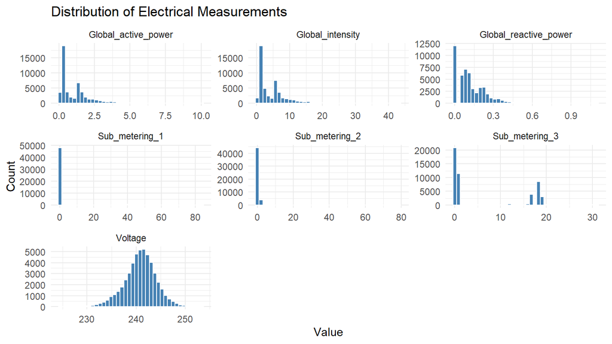

```r
# Distribution of each variable
power_sample %>%
  select(all_of(num_vars)) %>%
  pivot_longer(everything(), names_to = "Variable", values_to = "Value") %>%
  ggplot(aes(x = Value)) +
  geom_histogram(bins = 40, fill = "steelblue", colour = "white") +
  facet_wrap(~ Variable, scales = "free") +
  labs(title = "Distribution of Electrical Measurements",
       x = "Value", y = "Count") +
  theme_minimal()
```

# 10. Descriptive statistics

```r
# Summary statistics for each variable
power %>%
  summarise(across(all_of(num_vars),
                   list(mean = mean, sd = sd, median = median, min = min, max = max))) %>%
  pivot_longer(everything(),
               names_to = c("Variable", "Statistic"),
               names_pattern = "(.*)_(mean|sd|median|min|max)") %>%
  pivot_wider(names_from = Statistic, values_from = value) %>%
  mutate(across(where(is.numeric), ~ round(.x, 3))) %>%
  kable()
```

| Variable | mean | sd | median | min | max |
| --- | --- | --- | --- | --- | --- |
| Global_active_power | 1.092 | 1.057 | 0.602 | 0.076 | 11.122 |
| Global_reactive_power | 0.124 | 0.113 | 0.100 | 0.000 | 1.390 |
| Voltage | 240.840 | 3.240 | 241.010 | 223.200 | 254.150 |
| Global_intensity | 4.628 | 4.444 | 2.600 | 0.200 | 48.400 |
| Sub_metering_1 | 1.122 | 6.153 | 0.000 | 0.000 | 88.000 |
| Sub_metering_2 | 1.299 | 5.822 | 0.000 | 0.000 | 80.000 |
| Sub_metering_3 | 6.458 | 8.437 | 1.000 | 0.000 | 31.000 |

# 11. Time-based electricity consumption analysis

## Hour of the day

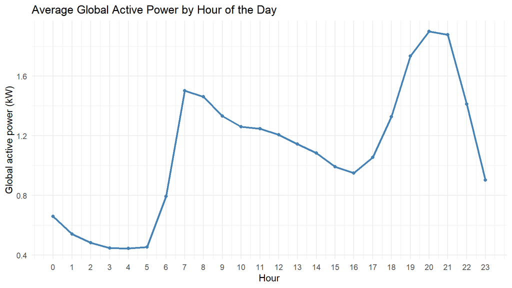

```r
# Average active power by hour
hourly <- power %>%
  group_by(Hour) %>%
  summarise(Mean_Power = mean(Global_active_power))

ggplot(hourly, aes(x = Hour, y = Mean_Power)) +
  geom_line(colour = "steelblue", linewidth = 1) +
  geom_point(colour = "steelblue") +
  scale_x_continuous(breaks = 0:23) +
  labs(title = "Average Global Active Power by Hour of the Day",
       x = "Hour", y = "Global active power (kW)") +
  theme_minimal()
```

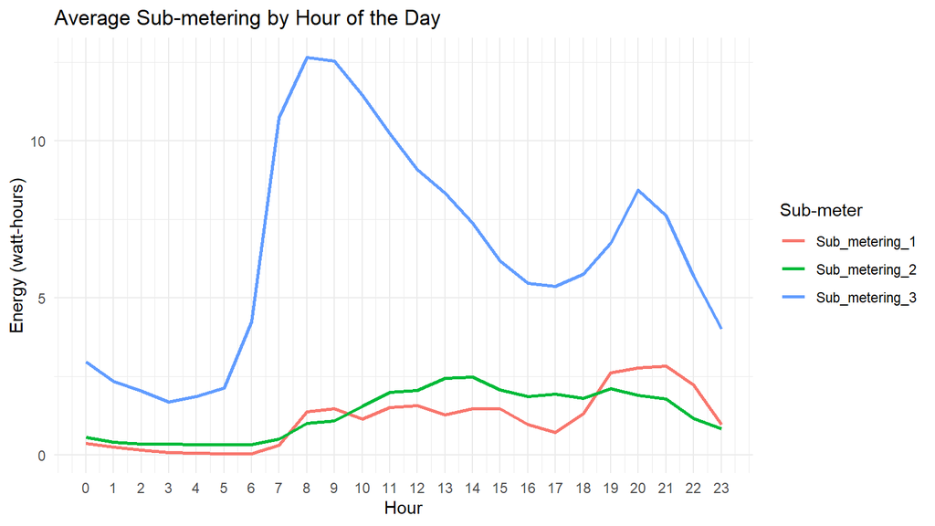

```r
# Average sub-metering by hour
power %>%
  group_by(Hour) %>%
  summarise(across(starts_with("Sub_metering"), mean)) %>%
  pivot_longer(-Hour, names_to = "Sub_metering", values_to = "Mean_Wh") %>%
  ggplot(aes(x = Hour, y = Mean_Wh, colour = Sub_metering)) +
  geom_line(linewidth = 1) +
  scale_x_continuous(breaks = 0:23) +
  labs(title = "Average Sub-metering by Hour of the Day",
       x = "Hour", y = "Energy (watt-hours)", colour = "Sub-meter") +
  theme_minimal()
```

## Day of the week

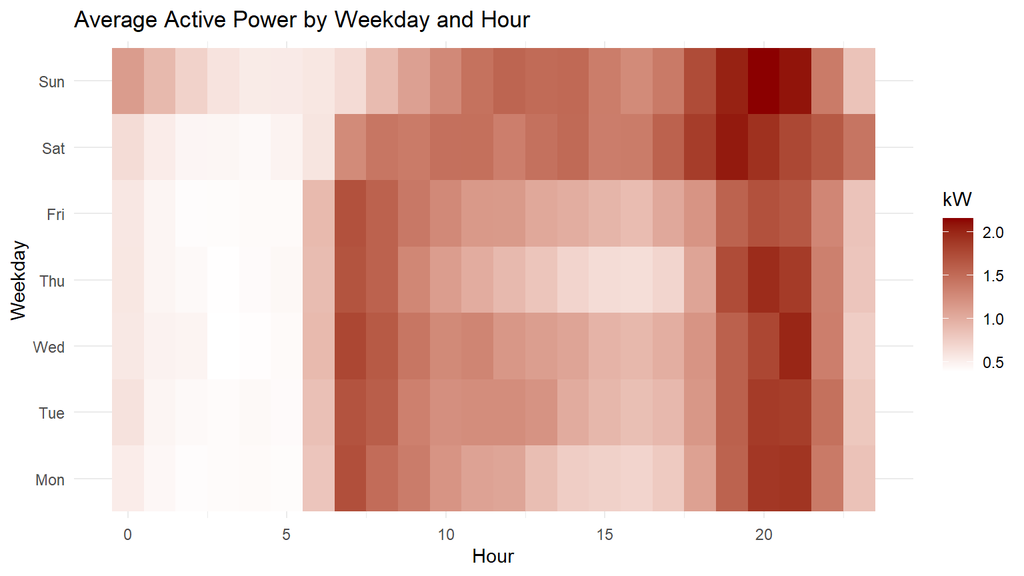

```r
# Average active power by weekday and hour
power %>%
  group_by(Weekday, Hour) %>%
  summarise(Mean_Power = mean(Global_active_power), .groups = "drop") %>%
  ggplot(aes(x = Hour, y = Weekday, fill = Mean_Power)) +
  geom_tile() +
  scale_fill_gradient(low = "white", high = "darkred") +
  labs(title = "Average Active Power by Weekday and Hour",
       x = "Hour", y = "Weekday", fill = "kW") +
  theme_minimal()
```

## Month and year

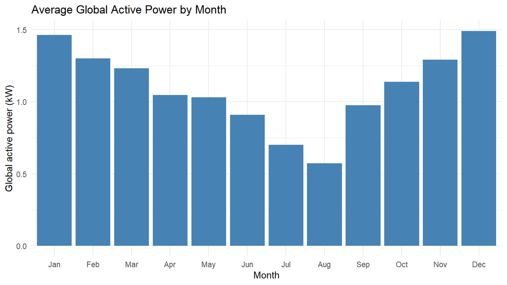

```r
# Average active power by calendar month
monthly <- power %>%
  group_by(Month) %>%
  summarise(Mean_Power = mean(Global_active_power))

ggplot(monthly, aes(x = Month, y = Mean_Power)) +
  geom_col(fill = "steelblue") +
  labs(title = "Average Global Active Power by Month",
       x = "Month", y = "Global active power (kW)") +
  theme_minimal()
```

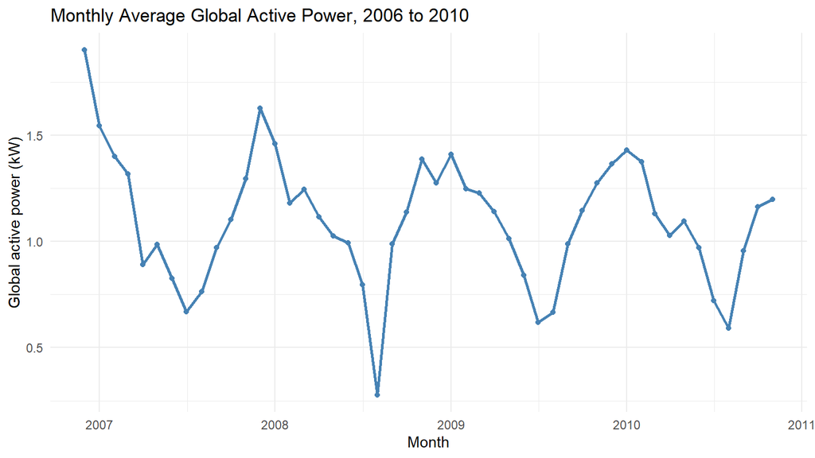

```r
# Monthly average over the whole period
monthly_series <- power %>%
  mutate(YearMonth = floor_date(DateTime, "month")) %>%
  group_by(YearMonth) %>%
  summarise(Mean_Power = mean(Global_active_power))

ggplot(monthly_series, aes(x = YearMonth, y = Mean_Power)) +
  geom_line(colour = "steelblue", linewidth = 1) +
  geom_point(colour = "steelblue") +
  labs(title = "Monthly Average Global Active Power, 2006 to 2010",
       x = "Month", y = "Global active power (kW)") +
  theme_minimal()
```

# 12. Correlation and covariation analysis

```r
# Correlation matrix of the measurement variables
cor_matrix <- cor(power[, num_vars])
round(cor_matrix, 2)
```

```
##                       Global_active_power Global_reactive_power Voltage
## Global_active_power                  1.00                  0.25   -0.40
## Global_reactive_power                0.25                  1.00   -0.11
## Voltage                             -0.40                 -0.11    1.00
## Global_intensity                     1.00                  0.27   -0.41
## Sub_metering_1                       0.48                  0.12   -0.20
## Sub_metering_2                       0.43                  0.14   -0.17
## Sub_metering_3                       0.64                  0.09   -0.27
##                       Global_intensity Sub_metering_1 Sub_metering_2
## Global_active_power               1.00           0.48           0.43
## Global_reactive_power             0.27           0.12           0.14
## Voltage                          -0.41          -0.20          -0.17
## Global_intensity                  1.00           0.49           0.44
## Sub_metering_1                    0.49           1.00           0.05
## Sub_metering_2                    0.44           0.05           1.00
## Sub_metering_3                    0.63           0.10           0.08
##                       Sub_metering_3
## Global_active_power             0.64
## Global_reactive_power           0.09
## Voltage                        -0.27
## Global_intensity                0.63
## Sub_metering_1                  0.10
## Sub_metering_2                  0.08
## Sub_metering_3                  1.00
```

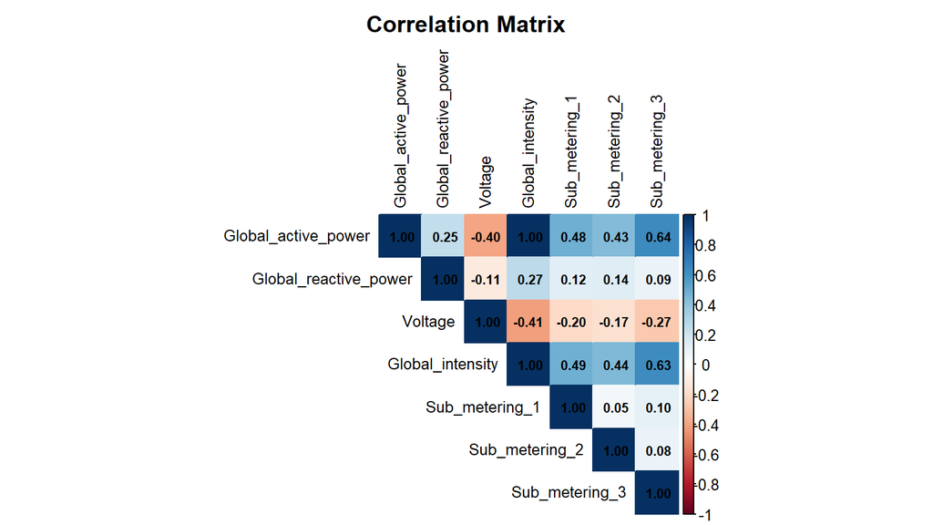

```r
corrplot(cor_matrix, method = "color", type = "upper",
         addCoef.col = "black", number.cex = 0.7,
         tl.col = "black", tl.cex = 0.8,
         title = "Correlation Matrix", mar = c(0, 0, 2, 0))
```

```r
# Variable pairs ranked by strength of correlation
cor_pairs <- as.data.frame(as.table(cor_matrix)) %>%
  filter(as.character(Var1) < as.character(Var2)) %>%
  mutate(Correlation = round(Freq, 3)) %>%
  select(Var1, Var2, Correlation) %>%
  arrange(desc(abs(Correlation)))
kable(cor_pairs)
```

| Var1 | Var2 | Correlation |
| --- | --- | --- |
| Global_active_power | Global_intensity | 0.999 |
| Global_active_power | Sub_metering_3 | 0.639 |
| Global_intensity | Sub_metering_3 | 0.627 |
| Global_intensity | Sub_metering_1 | 0.489 |
| Global_active_power | Sub_metering_1 | 0.484 |
| Global_intensity | Sub_metering_2 | 0.440 |
| Global_active_power | Sub_metering_2 | 0.435 |
| Global_intensity | Voltage | -0.411 |
| Global_active_power | Voltage | -0.400 |
| Sub_metering_3 | Voltage | -0.268 |
| Global_intensity | Global_reactive_power | 0.266 |
| Global_active_power | Global_reactive_power | 0.247 |
| Sub_metering_1 | Voltage | -0.196 |
| Sub_metering_2 | Voltage | -0.167 |
| Global_reactive_power | Sub_metering_2 | 0.139 |
| Global_reactive_power | Sub_metering_1 | 0.123 |
| Global_reactive_power | Voltage | -0.112 |
| Sub_metering_1 | Sub_metering_3 | 0.103 |
| Global_reactive_power | Sub_metering_3 | 0.090 |
| Sub_metering_2 | Sub_metering_3 | 0.081 |
| Sub_metering_1 | Sub_metering_2 | 0.055 |

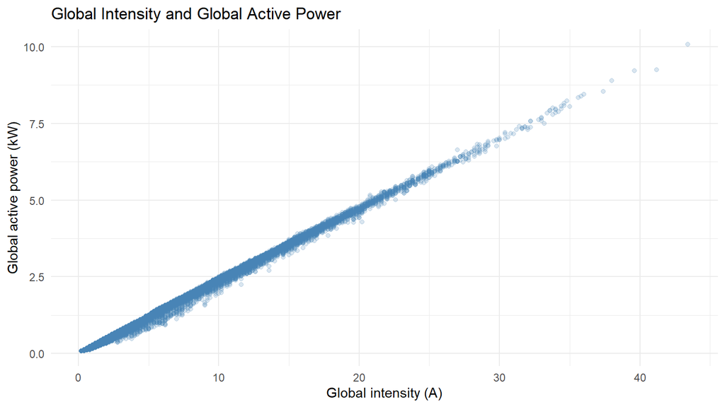

```r
# Scatterplots of selected pairs
ggplot(power_sample, aes(x = Global_intensity, y = Global_active_power)) +
  geom_point(alpha = 0.2, colour = "steelblue") +
  labs(title = "Global Intensity and Global Active Power",
       x = "Global intensity (A)", y = "Global active power (kW)") +
  theme_minimal()
```

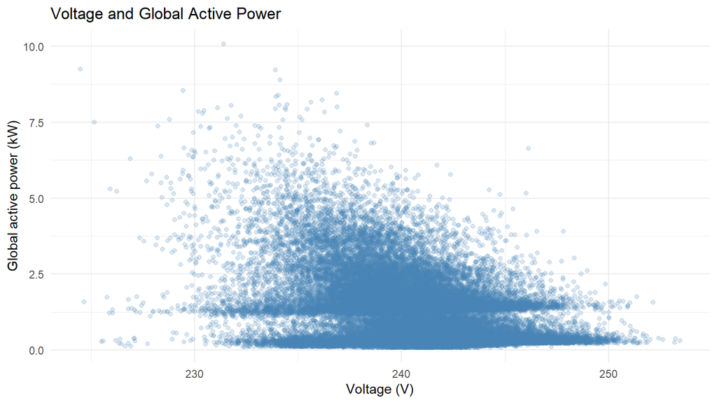

```r
ggplot(power_sample, aes(x = Voltage, y = Global_active_power)) +
  geom_point(alpha = 0.2, colour = "steelblue") +
  labs(title = "Voltage and Global Active Power",
       x = "Voltage (V)", y = "Global active power (kW)") +
  theme_minimal()
```

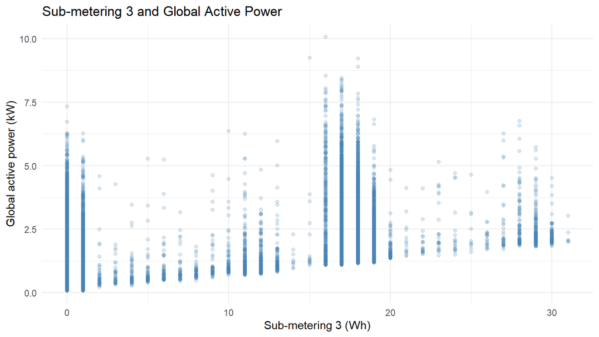

```r
ggplot(power_sample, aes(x = Sub_metering_3, y = Global_active_power)) +
  geom_point(alpha = 0.2, colour = "steelblue") +
  labs(title = "Sub-metering 3 and Global Active Power",
       x = "Sub-metering 3 (Wh)", y = "Global active power (kW)") +
  theme_minimal()
```

# 13. Unusual pattern identification

## When high readings happen

```r
# Upper fence for active power using the IQR rule
q <- quantile(power$Global_active_power, c(0.25, 0.75))
upper_fence <- q[2] + 1.5 * (q[2] - q[1])
upper_fence
```

```
##   75%
## 3.358
```

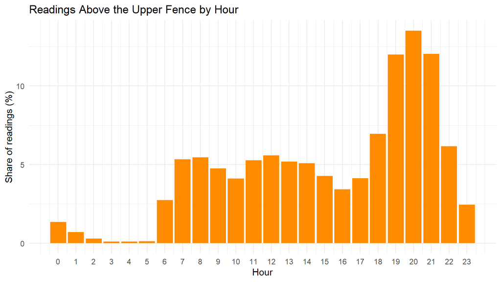

```r
# Share of readings above the fence in each hour
power %>%
  mutate(High = Global_active_power > upper_fence) %>%
  group_by(Hour) %>%
  summarise(Percent_High = 100 * mean(High)) %>%
  ggplot(aes(x = Hour, y = Percent_High)) +
  geom_col(fill = "darkorange") +
  scale_x_continuous(breaks = 0:23) +
  labs(title = "Readings Above the Upper Fence by Hour",
       x = "Hour", y = "Share of readings (%)") +
  theme_minimal()
```

## Unusual days

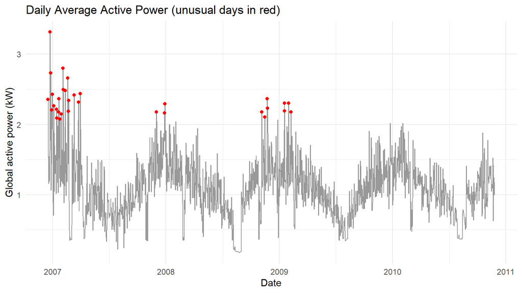

```r
# Daily average active power, using days with most of their readings
daily <- power %>%
  group_by(Date) %>%
  summarise(Mean_Power = mean(Global_active_power),
            Minutes = n()) %>%
  filter(Minutes >= 1200)

dq <- quantile(daily$Mean_Power, c(0.25, 0.75))
d_low <- dq[1] - 1.5 * (dq[2] - dq[1])
d_high <- dq[2] + 1.5 * (dq[2] - dq[1])

daily <- daily %>%
  mutate(Unusual = Mean_Power < d_low | Mean_Power > d_high)

ggplot(daily, aes(x = Date, y = Mean_Power)) +
  geom_line(colour = "grey60") +
  geom_point(data = filter(daily, Unusual), colour = "red", size = 1.5) +
  labs(title = "Daily Average Active Power (unusual days in red)",
       x = "Date", y = "Global active power (kW)") +
  theme_minimal()
```

```r
# Days with the lowest and highest average power
daily %>% arrange(Mean_Power) %>% head(5) %>% kable(caption = "Lowest days")
```

Lowest days

| Date | Mean_Power | Minutes | Unusual |
| --- | --- | --- | --- |
| 2008-08-25 | 0.1738181 | 1440 | FALSE |
| 2008-08-23 | 0.1768347 | 1440 | FALSE |
| 2008-08-24 | 0.1768861 | 1440 | FALSE |
| 2008-08-26 | 0.1788639 | 1440 | FALSE |
| 2008-08-27 | 0.1792458 | 1440 | FALSE |

```r
daily %>% arrange(desc(Mean_Power)) %>% head(5) %>% kable(caption = "Highest days")
```

Highest days

| Date | Mean_Power | Minutes | Unusual |
| --- | --- | --- | --- |
| 2006-12-23 | 3.314851 | 1440 | TRUE |
| 2007-02-03 | 2.798418 | 1440 | TRUE |
| 2006-12-26 | 2.732021 | 1440 | TRUE |
| 2007-02-18 | 2.659557 | 1440 | TRUE |
| 2007-02-04 | 2.497181 | 1440 | TRUE |

# 14. Categorical variable creation and one-hot encoding

A time period variable is created from the hour of the day, and then one-hot encoded.

```r
# Create the time period variable
power <- power %>%
  mutate(Time_Period = case_when(
    Hour >= 6  & Hour <= 11 ~ "Morning",
    Hour >= 12 & Hour <= 17 ~ "Afternoon",
    Hour >= 18 & Hour <= 21 ~ "Evening",
    TRUE ~ "Night"
  ),
  Time_Period = factor(Time_Period,
                       levels = c("Morning", "Afternoon", "Evening", "Night")))

table(power$Time_Period)
```

```
##
##   Morning Afternoon   Evening     Night
##    511650    512109    342033    683488
```

```r
# One-hot encoding of Time_Period
power <- power %>%
  mutate(Period_Morning   = as.integer(Time_Period == "Morning"),
         Period_Afternoon = as.integer(Time_Period == "Afternoon"),
         Period_Evening   = as.integer(Time_Period == "Evening"),
         Period_Night     = as.integer(Time_Period == "Night"))

# Check the encoding
power %>%
  select(Hour, Time_Period, starts_with("Period_")) %>%
  slice(c(1, 400, 800, 1200)) %>%
  kable()
```

| Hour | Time_Period | Period_Morning | Period_Afternoon | Period_Evening | Period_Night |
| --- | --- | --- | --- | --- | --- |
| 17 | Afternoon | 0 | 1 | 0 | 0 |
| 0 | Night | 0 | 0 | 0 | 1 |
| 6 | Morning | 1 | 0 | 0 | 0 |
| 13 | Afternoon | 0 | 1 | 0 | 0 |

```r
# Each row should have exactly one 1
table(rowSums(power[, c("Period_Morning", "Period_Afternoon",
                        "Period_Evening", "Period_Night")]))
```

```
##
##       1
## 2049280
```

```r
# Average consumption in each time period
power %>%
  group_by(Time_Period) %>%
  summarise(Mean_Power = mean(Global_active_power),
            Median_Power = median(Global_active_power)) %>%
  kable(digits = 3)
```

| Time_Period | Mean_Power | Median_Power |
| --- | --- | --- |
| Morning | 1.266 | 1.326 |
| Afternoon | 1.072 | 0.620 |
| Evening | 1.709 | 1.488 |
| Night | 0.667 | 0.348 |

The encoded columns are not used in the PCA. The PCA uses only the continuous electrical measurements, and the time period is used afterwards to help read the results.

# 15. Data standardisation

```r
# Standard deviations before standardising
sapply(power[, num_vars], sd)
```

```
##   Global_active_power Global_reactive_power               Voltage
##              1.057294              0.112722              3.239987
##      Global_intensity        Sub_metering_1        Sub_metering_2
##              4.444396              6.153031              5.822026
##        Sub_metering_3
##              8.437154
```

```r
# Standardise the measurement variables
power_scaled <- scale(as.matrix(power[, num_vars]))

# Check the result
round(colMeans(power_scaled), 4)
```

```
##   Global_active_power Global_reactive_power               Voltage
##                     0                     0                     0
##      Global_intensity        Sub_metering_1        Sub_metering_2
##                     0                     0                     0
##        Sub_metering_3
##                     0
```

```r
apply(power_scaled, 2, sd)
```

```
##   Global_active_power Global_reactive_power               Voltage
##                     1                     1                     1
##      Global_intensity        Sub_metering_1        Sub_metering_2
##                     1                     1                     1
##        Sub_metering_3
##                     1
```

# 16. Principal Component Analysis

PCA creates new variables (principal components) that are combinations of the original variables. The first component captures the most variation, the second captures the most of what remains, and so on. All seven continuous variables are used.

```r
# Run PCA on the standardised data
pca <- prcomp(power_scaled)

summary(pca)
```

```
## Importance of components:
##                           PC1    PC2    PC3    PC4    PC5     PC6     PC7
## Standard deviation     1.7972 0.9937 0.9657 0.9215 0.8845 0.46642 0.02713
## Proportion of Variance 0.4614 0.1411 0.1332 0.1213 0.1118 0.03108 0.00011
## Cumulative Proportion  0.4614 0.6025 0.7357 0.8570 0.9688 0.99989 1.00000
```

# 17. PCA variance analysis and scree plot

```r
# Eigenvalues and variance explained
eig <- get_eigenvalue(pca)
kable(round(eig, 3),
      col.names = c("Eigenvalue", "Variance (%)", "Cumulative variance (%)"))
```

|  | Eigenvalue | Variance (%) | Cumulative variance (%) |
| --- | --- | --- | --- |
| Dim.1 | 3.230 | 46.144 | 46.144 |
| Dim.2 | 0.987 | 14.106 | 60.249 |
| Dim.3 | 0.933 | 13.323 | 73.572 |
| Dim.4 | 0.849 | 12.132 | 85.704 |
| Dim.5 | 0.782 | 11.177 | 96.882 |
| Dim.6 | 0.218 | 3.108 | 99.989 |
| Dim.7 | 0.001 | 0.011 | 100.000 |

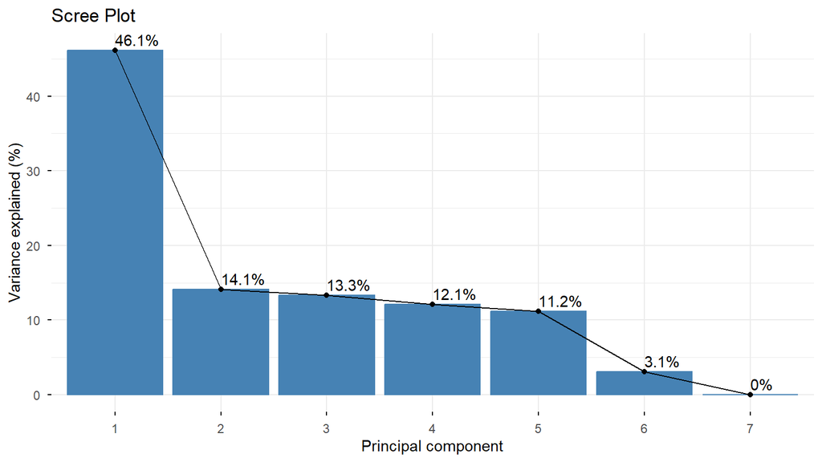

```r
# Scree plot
fviz_eig(pca, addlabels = TRUE, ncp = 7,
         barfill = "steelblue", barcolor = "steelblue",
         main = "Scree Plot", xlab = "Principal component",
         ylab = "Variance explained (%)")
```

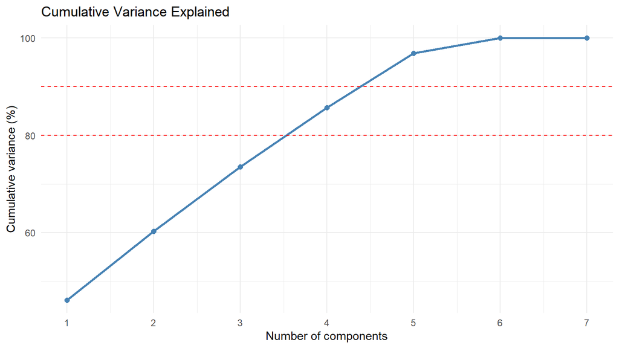

```r
# Cumulative variance plot
cum_var <- tibble(PC = 1:nrow(eig),
                  Cumulative = eig$cumulative.variance.percent)

ggplot(cum_var, aes(x = PC, y = Cumulative)) +
  geom_line(colour = "steelblue", linewidth = 1) +
  geom_point(colour = "steelblue", size = 2) +
  geom_hline(yintercept = c(80, 90), linetype = "dashed", colour = "red") +
  scale_x_continuous(breaks = 1:nrow(eig)) +
  labs(title = "Cumulative Variance Explained",
       x = "Number of components", y = "Cumulative variance (%)") +
  theme_minimal()
```

```r
# Components needed for 80% and 90% of the variance
n_80 <- which(eig$cumulative.variance.percent >= 80)[1]
n_90 <- which(eig$cumulative.variance.percent >= 90)[1]

# Components with an eigenvalue above 1
n_kaiser <- sum(eig$eigenvalue > 1)
```

The first component explains 46.1% of the variance. 4 components are needed to pass 80% of the variance and 5 components to pass 90%. 1 components have an eigenvalue above 1.

# 18. PCA visualisations and variable loadings

```r
# Loadings of the first three components
kable(round(pca$rotation[, 1:3], 3))
```

|  | PC1 | PC2 | PC3 |
| --- | --- | --- | --- |
| Global_active_power | -0.538 | -0.051 | 0.030 |
| Global_reactive_power | -0.187 | 0.670 | -0.340 |
| Voltage | 0.296 | 0.142 | -0.060 |
| Global_intensity | -0.540 | -0.032 | 0.019 |
| Sub_metering_1 | -0.295 | -0.100 | -0.741 |
| Sub_metering_2 | -0.266 | 0.573 | 0.500 |
| Sub_metering_3 | -0.372 | -0.434 | 0.283 |

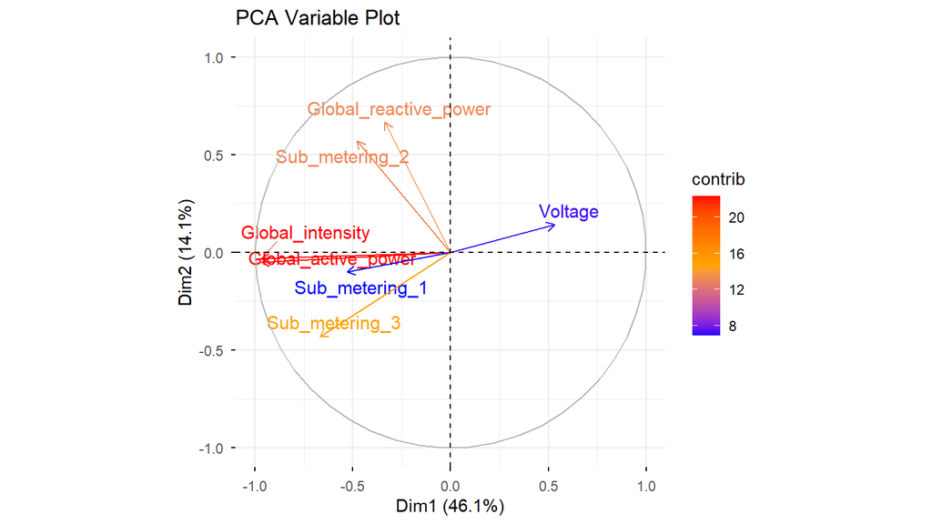

```r
# Variable plot for the first two components
fviz_pca_var(pca, col.var = "contrib",
             gradient.cols = c("blue", "orange", "red"),
             repel = TRUE,
             title = "PCA Variable Plot")
```

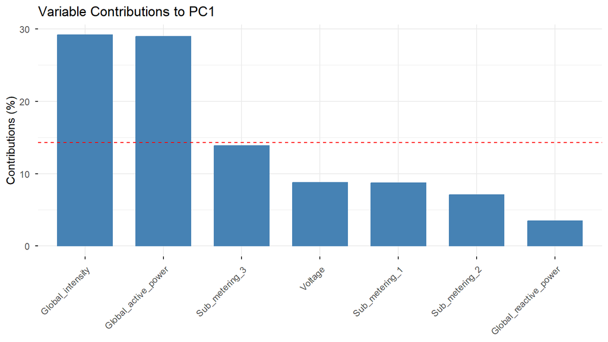

```r
# Contribution of each variable to PC1 and PC2
fviz_contrib(pca, choice = "var", axes = 1, fill = "steelblue",
             color = "steelblue", title = "Variable Contributions to PC1")
```

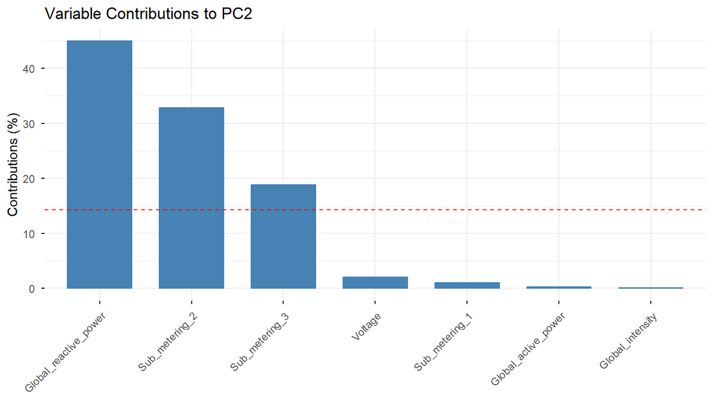

```r
fviz_contrib(pca, choice = "var", axes = 2, fill = "steelblue",
             color = "steelblue", title = "Variable Contributions to PC2")
```

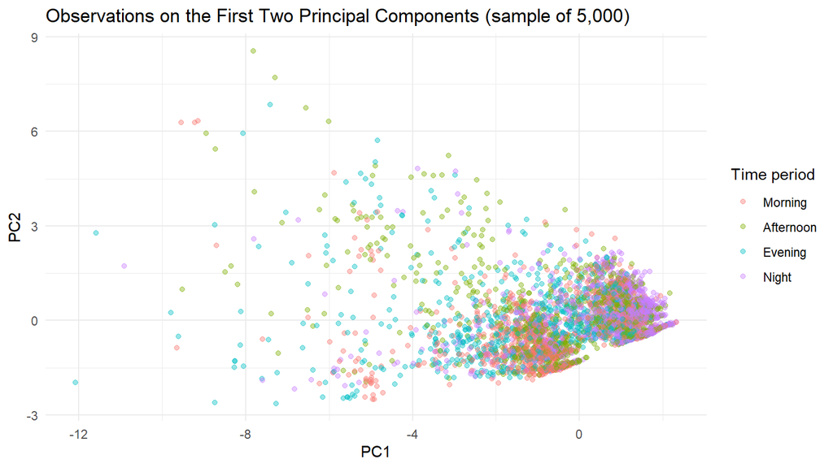

```r
# PC scores for a random sample of observations, coloured by time period
set.seed(123)
sample_rows <- sample(nrow(power), 5000)

scores <- data.frame(PC1 = pca$x[sample_rows, 1],
                     PC2 = pca$x[sample_rows, 2],
                     Time_Period = power$Time_Period[sample_rows])

ggplot(scores, aes(x = PC1, y = PC2, colour = Time_Period)) +
  geom_point(alpha = 0.4) +
  labs(title = "Observations on the First Two Principal Components (sample of 5,000)",
       x = "PC1", y = "PC2", colour = "Time period") +
  theme_minimal()
```

```r
# Average PC1 and PC2 score in each time period
tibble(Time_Period = power$Time_Period,
       PC1 = pca$x[, 1],
       PC2 = pca$x[, 2]) %>%
  group_by(Time_Period) %>%
  summarise(Mean_PC1 = mean(PC1), Mean_PC2 = mean(PC2)) %>%
  kable(digits = 3)
```

| Time_Period | Mean_PC1 | Mean_PC2 |
| --- | --- | --- |
| Morning | -0.392 | -0.338 |
| Afternoon | -0.042 | 0.127 |
| Evening | -0.967 | 0.060 |
| Night | 0.810 | 0.128 |

# 19. Discussion and interpretation

Question 1 + Main question - Variation over time: Consumption is associated with domestic patterns. The morning peak is observed at 07:00 (1.5 kW) and the evening peak at 20:00 (1.9 kW), while night time consumption is low between 03:00 and 05:00 (0.45 kW). Weekdays show a morning peak and reduced daytime consumption later on. On weekends there is higher daytime consumption which corresponds to time people are at home.

Question 2 - Correlations: Active power and intensity are strongly correlated (r = 0.99). This is expected as power and intensity are directly proportional at a constant voltage. Sub_metering_3 is also highly correlated with total power amongst the sub meters (0.64). Voltage and load are negatively correlated (-0.41). The sub meters are only weakly correlated with each other (0.05 - 0.10). This is likely due to different appliances being used at different times.

Question 3 - Anomalies: There are many outliers in the sub meters and in active power (4.63%). However these are all actual appliance events and the maximum active power recorded is 11.12 kW, and these have been retained. Days with very high consumption are more common in the winter. December 2006 to March 2007 show many of these days. The days with lowest consumption occur in August 2008, which may suggest low consumption period even though it is not captured by data.

Question 4 - Contribution to variation: Active power and intensity are the main contributors to PC1 with a combined contribution of approximately 58%, and from Sub_metering_3 as well. Sub_metering_2 and reactive power make a contribution to PC2. Active power and intensity are nearly identical and so they contribute redundant information which causes PC1 to appear more important than if either was used alone.

Question 5 - Dimensionality reduction: 85.7% of the variation is captured by four components, therefore it is possible to reduce the number of variables from seven to five as they are the only ones needed to reach 90%. PC7 makes a minimal contribution (0.01%) and this is likely due to the strong relationship between active power and intensity.

# 20. Conclusion

Consumption follows a clear daily rhythm and is higher in winter. Power and intensity carry almost identical information. PC1–PC4 hold 85.7% of the variance, so four components keep most of the information. Active power and intensity matter most for PC1, while reactive power and Sub_metering_2 are for PC2.

# 21. Limitations

- The data comes from one household, so the patterns cannot be applied to all households.
- The data covers about four years, so long-term trends and unusual years are hard to separate.
- Rows with missing values were removed, which leaves gaps in the time series.
- Minute-level readings that are close in time are not independent, so statistical tests that assume independence would not be appropriate.
- The sub-meters do not cover all appliances in the house, so part of the consumption is not measured by them.
- Global active power, global intensity and voltage are linked through the physics of electricity, so some variables carry overlapping information.
- PCA only finds linear patterns, and it is sensitive to extreme values, which were kept in the data.
- The time periods used for the categorical variable are a simple choice and other cut-offs could give different results.

# 22. Harvard-style references

Grolemund, G. and Wickham, H. (2011) ‘Dates and times made easy with lubridate’, *Journal of Statistical Software*, 40(3), pp. 1-25. doi:10.18637/jss.v040.i03.

Hebrail, G. and Berard, A. (2012) *Individual household electric power consumption*. UCI Machine Learning Repository. Available at: https://doi.org/10.24432/C58K54 (Accessed: 18 November 2026).

Jolliffe, I.T. and Cadima, J. (2016) ‘Principal component analysis: a review and recent developments’, *Philosophical Transactions of the Royal Society A*, 374(2065), 20150202. doi:10.1098/rsta.2015.0202.

Kassambara, A. and Mundt, F. (2020) *factoextra: Extract and visualize the results of multivariate data analyses*. R package. Available at: https://CRAN.R-project.org/package=factoextra (Accessed: 18 November 2026).

R Core Team (2024) *R: A language and environment for statistical computing*. Vienna: R Foundation for Statistical Computing. Available at: https://www.R-project.org/ (Accessed: 18 November 2026).

Wei, T. and Simko, V. (2021) *R package ‘corrplot’: Visualization of a correlation matrix*. Available at: https://github.com/taiyun/corrplot (Accessed: 18 November 2026).

Wickham, H. et al. (2019) ‘Welcome to the tidyverse’, *Journal of Open Source Software*, 4(43), p. 1686. doi:10.21105/joss.01686.

Xie, Y., Allaire, J.J. and Grolemund, G. (2018) *R Markdown: The definitive guide*. Boca Raton: Chapman and Hall/CRC.